# Ερώτηση 2

```python
import pandas as pd #anagaies vivliothies

import matplotlib.pyplot as plt
import seaborn as sns
import numpy as np
```

διαβάζω το αρχείο και φτιάχνω dataframe για αυτό

```python
df = pd.read_csv('data.csv')
```

Οι πρώτες 5 σειρές του αρχείου. Ακολουθεί περιγραφή των δεδομένων του dataframe.

```python
print(df.head())
print(df.describe())
```

```
            A         B         C
0  260.294178  6.023530  6.250190
1  573.184326  6.216912  8.122399
2  278.184850  5.984904  6.941317
3  840.307132  7.094901  9.898640
4  489.451457  5.807850  7.788574
                 A            B            C
count  1000.000000  1000.000000  1000.000000
mean    511.800289     5.910720     7.541597
std     292.492959     1.050890     1.993840
min       1.390116     0.045241     1.244524
25%     263.453204     5.491083     6.425420
50%     523.052756     6.218248     8.027734
75%     770.292393     6.589739     9.129594
max    1000.627658     7.370952    10.349967
```

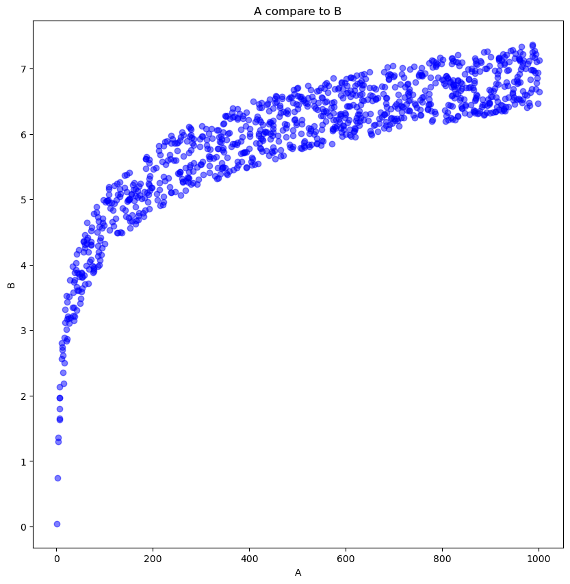

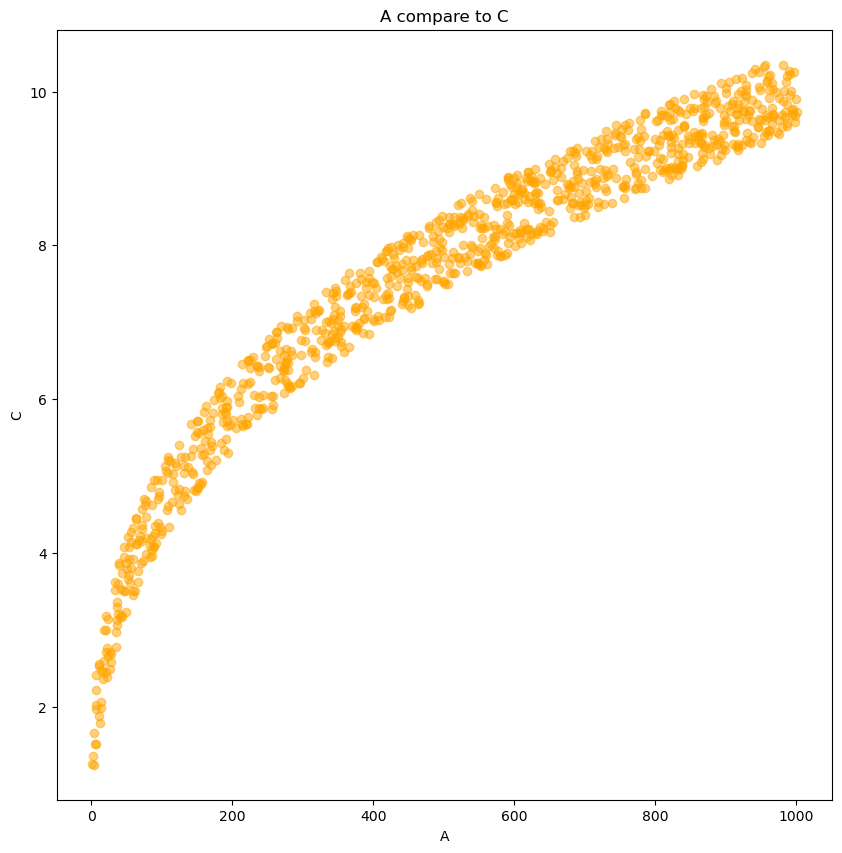

```python
#2 figures per A -> B AND A -> C
plt.figure(figsize=(10,10))
plt.scatter(df["A"],df["B"],alpha = 0.5 , color = 'blue')
plt.xlabel('A')
plt.ylabel('B')
plt.title("A compare to B")
plt.show()





plt.figure(figsize=(10,10))
plt.scatter(df["A"],df["C"],alpha = 0.5 , color = 'orange')
plt.xlabel('A')
plt.ylabel('C')
plt.title("A compare to C")
plt.show()
```

Γραμμική αναπαράσταση με sort ascending Α

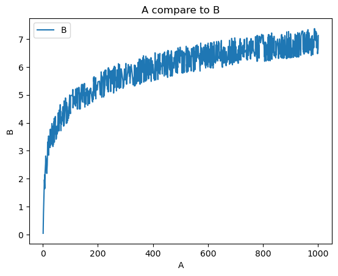

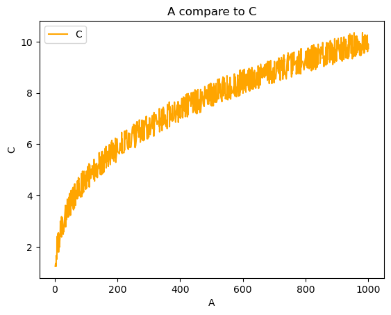

```python
dfsort = df.sort_values(by='A',ascending = True)
plt.figure
dfsort.plot(x='A',y = 'B')
plt.xlabel('A')
plt.ylabel('B')
plt.title("A compare to B")
plt.show()


plt.figure
dfsort.plot(x='A',y = 'C',color = 'orange')
plt.xlabel('A')
plt.ylabel('C')
plt.title("A compare to C")
plt.show()
```

Γραμμική αναπαράσταση χωρίς σορτάρισμα τιμών

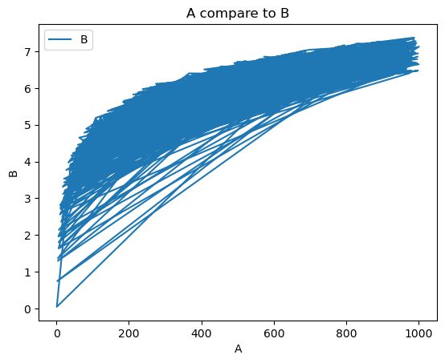

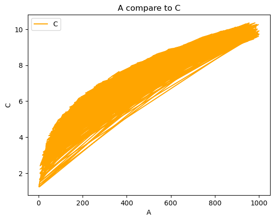

```python
plt.figure
df.plot(x='A',y = 'B')
plt.xlabel('A')
plt.ylabel('B')
plt.title("A compare to B")
plt.show()


plt.figure
df.plot(x='A',y = 'C',color = 'orange')
plt.xlabel('A')
plt.ylabel('C')
plt.title("A compare to C")
plt.show()
```

Πίνακας συσχέτισης ανάμεσα στα a,b,c. Oι τιμές κοντά στο 1 δείχνουν δυνατή συσχέτιση ανάμεσα στις συναρτήσεις ενώ τιμές κοντά στο 0 αδύνατες συσχετήσεις.

```python
correlation_matrix = df[['A','B','C']].corr()
print(correlation_matrix['A'])
```

```
A    1.000000
B    0.838387
C    0.945450
Name: A, dtype: float64
```

Παρατηρώ την αύξηση θορύβου όσο μεγαλώνουν οι τιμές του Β,C ως προς Α. Από τις γραφικές παραστάσεις καταλαβαίνουμε ότι ο τύπος των συναρτήσεων είναι λογαριθμικός και ότι υπάρχει δυνατή συσχετισή ανάμεσα στις Α, Β και στις Α, C.

Στις παραστάσεις που ακολουθούν έχω θέσει σε ίδια κλίμακα τα δεδομένα για να μην υπάρχουν μεγάλες διαφοροποιήσεις. Εφαρμόζω κανονικοποίηση λογαρίθμου. Αυτο έχει ώς απόρροια, οι τιμές να πολυ μικρότερες και έτσι τα δεδομένα να είναι πιο διαχειρίσιμα, αλλά και πιο χρήσιμα για την εξαγωγή συμπερασμάτων.

Το df_log_show έχει ως στήλες τις κανονικοποιήμενες στήλες Α,Β,C

```python
df_log_show = pd.DataFrame(np.log(df["A"]))
log_B = np.log(df["B"])
log_C = np.log(df["C"])

df_log_show = df_log_show.join(log_B)
df_log_show = df_log_show.join(log_C)
print(df_log_show)
```

```
            A         B         C
0    5.561812  1.795674  1.832612
1    6.351207  1.827273  2.094626
2    5.628286  1.789240  1.937492
3    6.733767  1.959376  2.292397
4    6.193285  1.759210  2.052658
..        ...       ...       ...
995  6.708611  1.884511  2.285354
996  6.454990  1.873768  2.146425
997  6.031447  1.834927  1.956327
998  6.730470  1.896821  2.201271
999  6.352259  1.924508  2.145778

[1000 rows x 3 columns]
```

scatter for df_log_show

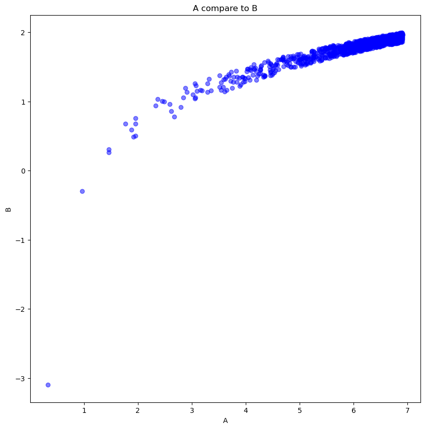

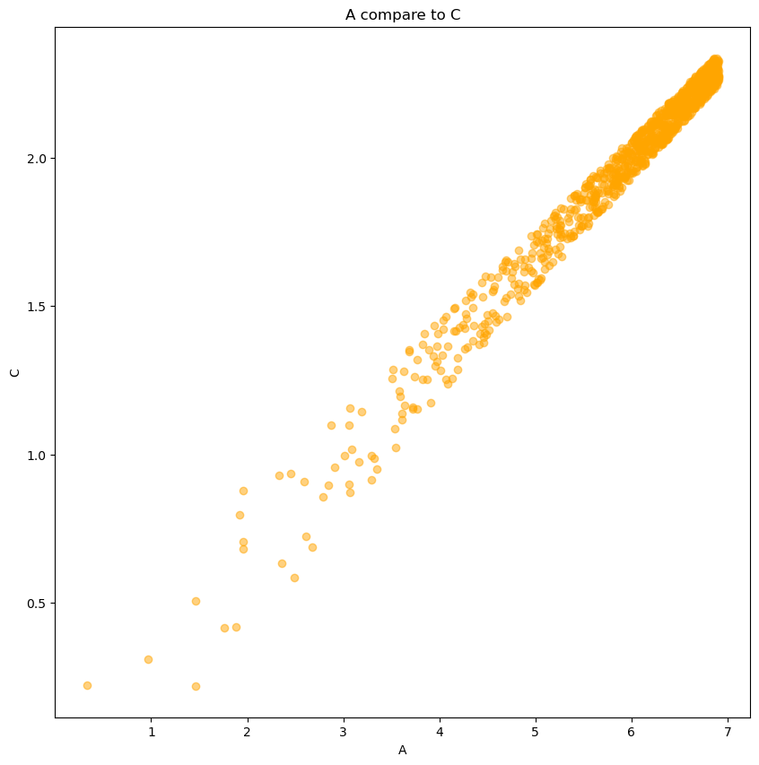

```python
plt.figure(figsize=(10,10))
plt.scatter(df_log_show["A"],df_log_show["B"],alpha = 0.5 , color = 'blue')
plt.xlabel('A')
plt.ylabel('B')
plt.title("A compare to B")
plt.show()


plt.figure(figsize=(10,10))
plt.scatter(df_log_show["A"],df_log_show["C"],alpha = 0.5 , color = 'orange')
plt.xlabel('A')
plt.ylabel('C')
plt.title("A compare to C")
plt.show()
```

μειώνεται ο θόρυβος ψηλά.

```
Correlation : 0.8686300778899727
```

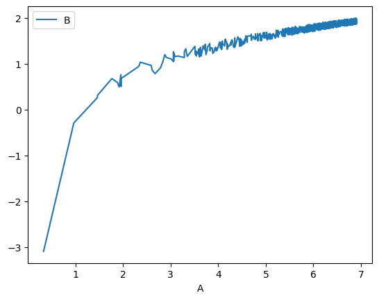

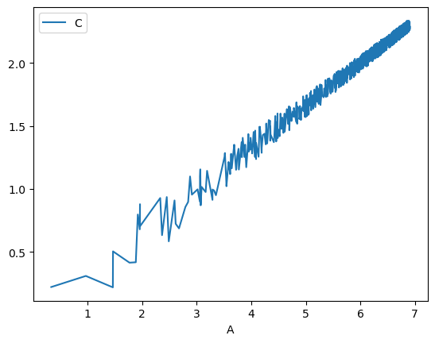

```python
df_log_show = df_log_show.sort_values(by='A', ascending = True)
plt.figure();
df_log_show.plot(x = 'A', y = 'B');
plt.figure();
df_log_show.plot(x = 'A', y = 'C');

print('Correlation :',df_log_show['A'].corr(df_log_show['B']))
```

```
1.8274881441979705
6.25968165469307
```

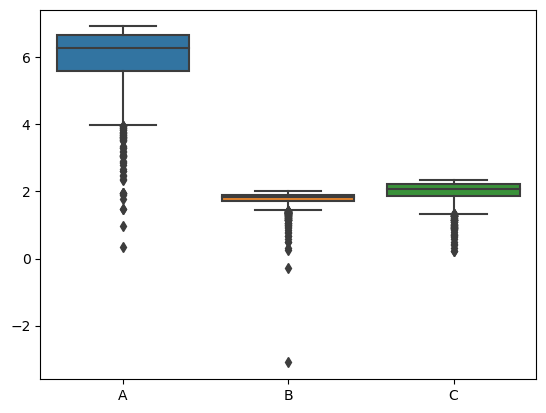

```python
sns.boxplot(data = df_log_show)
print(df_log_show['B'].median())
print(df_log_show['A'].median())
```